# Project 1: Wrangling, Exploration, Visualization

SDS322E

## Data Wrangling, Exploration, Visualization

### Arnav Patel (AP53888)

### Introduction

After ‘scrolling til my eyes bled’ through the different potential data sets that the R library has, I found one called States which is a data set that has data about Education in the US based on states from the year 1992. The data set had 8 variables - region (this includes ENC, East North Central; ESC, East South Central; MA, Mid-Atlantic; MTN, Mountain; NE, New England; PAC, Pacific; SA, South Atlantic; WNC, West North Central; WSC, West South Central), population, average SAT verbal and math scores, percent of high-schoolers who took the SAT, average amount of money spent on public education per student, and the average teacher’s salary in the state. Wondering how these states would be correlated to political party, I made my own data set using data from Harvard’s already existing databases that contained information on what the political party candidate each state voted on during the 1992 presidential election and how many electoral votes those states each had. These data sets interest me because I wanted to see if there was any correlation between spending on public education state by state and the states political affiliations. I hypothesized that the states that voted for the Democratic candidate, Bill Clinton, would be correlated with higher state spending on public education.

```r
# read your datasets in here, e.g., with read_csv()
library(tidyverse)
library(carData)

# First Dataset (Education and Related Statistics for the
# U.S. States in 1992)
edu <- States
edu <- edu %>% mutate(state = rownames(.))
view(edu)
glimpse(edu)
```

```
## Rows: 51
## Columns: 8
## $ region  <fct> ESC, PAC, MTN, WSC, PAC, MTN, NE, SA, SA, SA, SA, PAC, MTN, E…
## $ pop     <int> 4041, 550, 3665, 2351, 29760, 3294, 3287, 666, 607, 12938, 64…
## $ SATV    <int> 470, 438, 445, 470, 419, 456, 430, 433, 409, 418, 401, 404, 4…
## $ SATM    <int> 514, 476, 497, 511, 484, 513, 471, 470, 441, 466, 443, 481, 5…
## $ percent <int> 8, 42, 25, 6, 45, 28, 74, 58, 68, 44, 57, 52, 17, 16, 54, 5, …
## $ dollars <dbl> 3.648, 7.887, 4.231, 3.334, 4.826, 4.809, 7.914, 6.016, 8.210…
## $ pay     <int> 27, 43, 30, 23, 39, 31, 43, 35, 39, 30, 29, 32, 25, 34, 32, 2…
## $ state   <chr> "AL", "AK", "AZ", "AR", "CA", "CO", "CN", "DE", "DC", "FL", "…
```

```r
# Second Dataset (How many electoral votes and what party was
# voted for in 1992)
Election <- read_csv("Election.csv")
view(Election)
glimpse(Election)
```

```
## Rows: 51
## Columns: 3
## $ state_po        <chr> "AL", "AK", "AZ", "AR", "CA", "CO", "CT", "DE", "DC",…
## $ Party_Voted     <chr> "Republican", "Republican", "Republican", "Democrat",…
## $ Electoral_Votes <dbl> 9, 3, 8, 6, 54, 8, 8, 3, 3, 25, 13, 4, 4, 22, 12, 7, …
```

### Tidying: Reshaping

```r
# your tidying code (if applicable; can also wait until
# wrangling section)
edu_untidy <- edu %>% pivot_longer(cols = starts_with("SAT"),
    names_to = "test", values_to = "score")
view(edu_untidy)
glimpse(edu_untidy)
```

```
## Rows: 102
## Columns: 8
## $ region  <fct> ESC, ESC, PAC, PAC, MTN, MTN, WSC, WSC, PAC, PAC, MTN, MTN, N…
## $ pop     <int> 4041, 4041, 550, 550, 3665, 3665, 2351, 2351, 29760, 29760, 3…
## $ percent <int> 8, 8, 42, 42, 25, 25, 6, 6, 45, 45, 28, 28, 74, 74, 58, 58, 6…
## $ dollars <dbl> 3.648, 3.648, 7.887, 7.887, 4.231, 4.231, 3.334, 3.334, 4.826…
## $ pay     <int> 27, 27, 43, 43, 30, 30, 23, 23, 39, 39, 31, 31, 43, 43, 35, 3…
## $ state   <chr> "AL", "AL", "AK", "AK", "AZ", "AZ", "AR", "AR", "CA", "CA", "…
## $ test    <chr> "SATV", "SATM", "SATV", "SATM", "SATV", "SATM", "SATV", "SATM…
## $ score   <int> 470, 514, 438, 476, 445, 497, 470, 511, 419, 484, 456, 513, 4…
```

```r
edu_tidy <- edu_untidy %>% pivot_wider(names_from = "test", values_from = "score")
view(edu_tidy)
glimpse(edu_tidy)
```

```
## Rows: 51
## Columns: 8
## $ region  <fct> ESC, PAC, MTN, WSC, PAC, MTN, NE, SA, SA, SA, SA, PAC, MTN, E…
## $ pop     <int> 4041, 550, 3665, 2351, 29760, 3294, 3287, 666, 607, 12938, 64…
## $ percent <int> 8, 42, 25, 6, 45, 28, 74, 58, 68, 44, 57, 52, 17, 16, 54, 5, …
## $ dollars <dbl> 3.648, 7.887, 4.231, 3.334, 4.826, 4.809, 7.914, 6.016, 8.210…
## $ pay     <int> 27, 43, 30, 23, 39, 31, 43, 35, 39, 30, 29, 32, 25, 34, 32, 2…
## $ state   <chr> "AL", "AK", "AZ", "AR", "CA", "CO", "CN", "DE", "DC", "FL", "…
## $ SATV    <int> 470, 438, 445, 470, 419, 456, 430, 433, 409, 418, 401, 404, 4…
## $ SATM    <int> 514, 476, 497, 511, 484, 513, 471, 470, 441, 466, 443, 481, 5…
```

Because my data sets were already tidy, I decided to first untidy them and then retidy them. What I did to untidy them is using pivot longer, I took the separate columns of SAT verbal and math scores and made one new column called “test” that would say whether the test being referred to in that row was either the SAT verbal or SAT math test and then another column called “score” that would have the score of the respective test in the row. This unnecessarily cause the data set to have exactly twice as many rows. In order to tidy it, I returned the data set back to the original set using pivot wider.

### Joining/Merging

```r
# your joining code
edu <- edu %>% rename(state_po = state)
edu[7, 8] = "CT"

EduElect <- full_join(edu, Election, by = "state_po")
view(EduElect)
glimpse(EduElect)
```

```
## Rows: 51
## Columns: 10
## $ region          <fct> ESC, PAC, MTN, WSC, PAC, MTN, NE, SA, SA, SA, SA, PAC…
## $ pop             <int> 4041, 550, 3665, 2351, 29760, 3294, 3287, 666, 607, 1…
## $ SATV            <int> 470, 438, 445, 470, 419, 456, 430, 433, 409, 418, 401…
## $ SATM            <int> 514, 476, 497, 511, 484, 513, 471, 470, 441, 466, 443…
## $ percent         <int> 8, 42, 25, 6, 45, 28, 74, 58, 68, 44, 57, 52, 17, 16,…
## $ dollars         <dbl> 3.648, 7.887, 4.231, 3.334, 4.826, 4.809, 7.914, 6.01…
## $ pay             <int> 27, 43, 30, 23, 39, 31, 43, 35, 39, 30, 29, 32, 25, 3…
## $ state_po        <chr> "AL", "AK", "AZ", "AR", "CA", "CO", "CT", "DE", "DC",…
## $ Party_Voted     <chr> "Republican", "Republican", "Republican", "Democrat",…
## $ Electoral_Votes <dbl> 9, 3, 8, 6, 54, 8, 8, 3, 3, 25, 13, 4, 4, 22, 12, 7, …
```

```r
Inner <- inner_join(edu, Election, by = "state_po")
view(Inner)
glimpse(Inner)
```

```
## Rows: 51
## Columns: 10
## $ region          <fct> ESC, PAC, MTN, WSC, PAC, MTN, NE, SA, SA, SA, SA, PAC…
## $ pop             <int> 4041, 550, 3665, 2351, 29760, 3294, 3287, 666, 607, 1…
## $ SATV            <int> 470, 438, 445, 470, 419, 456, 430, 433, 409, 418, 401…
## $ SATM            <int> 514, 476, 497, 511, 484, 513, 471, 470, 441, 466, 443…
## $ percent         <int> 8, 42, 25, 6, 45, 28, 74, 58, 68, 44, 57, 52, 17, 16,…
## $ dollars         <dbl> 3.648, 7.887, 4.231, 3.334, 4.826, 4.809, 7.914, 6.01…
## $ pay             <int> 27, 43, 30, 23, 39, 31, 43, 35, 39, 30, 29, 32, 25, 3…
## $ state_po        <chr> "AL", "AK", "AZ", "AR", "CA", "CO", "CT", "DE", "DC",…
## $ Party_Voted     <chr> "Republican", "Republican", "Republican", "Democrat",…
## $ Electoral_Votes <dbl> 9, 3, 8, 6, 54, 8, 8, 3, 3, 25, 13, 4, 4, 22, 12, 7, …
```

```r
Anti <- anti_join(edu, Election, by = "state_po")
view(Anti)
glimpse(Anti)
```

```
## Rows: 0
## Columns: 8
## $ region   <fct>
## $ pop      <int>
## $ SATV     <int>
## $ SATM     <int>
## $ percent  <int>
## $ dollars  <dbl>
## $ pay      <int>
## $ state_po <chr>
```

When I first tried to join the two data sets together I ran into two hiccups. To make it easier for me to join, I renamed the ‘state’ variable in the Education data set to ‘state_po’ so I could join them by ‘state_po’. The other hiccup I noticed was that there was no data showing for Connecticut. This was because in the Education data set, the initials for Connecticut were “CN”. I had to change this to “CT” to get all the proper data. I used a full join because I wanted to see all of the data from the two data sets before I manipulated it to see everything I had in my hands. Both the education and the election data sets originally had 51 unique rows (one row for each state + Washington DC) and because I joined them by state, the new joined data set also had 51 unique rows meaning no rows were dropped. There were no row IDs that appeared in one data set but not the other which is why there were 51 row IDs in common between the two data sets.

### Wrangling

```r
# (six core dplyr functions) FILTER to get data of only
# states that voted for the Democratic candidate
EduElect %>% filter(Party_Voted == "Democrat")
```

```
##    region   pop SATV SATM percent dollars pay state_po Party_Voted
## 1     WSC  2351  470  511       6   3.334  23       AR    Democrat
## 2     PAC 29760  419  484      45   4.826  39       CA    Democrat
## 3     MTN  3294  456  513      28   4.809  31       CO    Democrat
## 4      NE  3287  430  471      74   7.914  43       CT    Democrat
## 5      SA   666  433  470      58   6.016  35       DE    Democrat
## 6      SA   607  409  441      68   8.210  39       DC    Democrat
## 7      SA  6478  401  443      57   4.860  29       GA    Democrat
## 8     PAC  1108  404  481      52   5.008  32       HI    Democrat
## 9     ENC 11431  466  528      16   5.062  34       IL    Democrat
## 10    WNC  2777  511  577       5   4.839  28       IA    Democrat
##    Electoral_Votes
## 1                6
## 2               54
## 3                8
## 4                8
## 5                3
## 6                3
## 7               13
## 8                4
## 9               22
## 10               7
##  [ reached 'max' / getOption("max.print") -- omitted 23 rows ]
```

```r
# ARRANGE to see which states have the most electoral votes
EduElect %>% arrange(desc(Electoral_Votes))
```

```
##    region   pop SATV SATM percent dollars pay state_po Party_Voted
## 1     PAC 29760  419  484      45   4.826  39       CA    Democrat
## 2      MA 17990  412  470      70   8.500  42       NY    Democrat
## 3     WSC 16987  413  461      42   4.238  28       TX  Republican
## 4      SA 12938  418  466      44   5.154  30       FL  Republican
## 5      MA 11882  420  463      64   6.534  36       PA    Democrat
## 6     ENC 11431  466  528      16   5.062  34       IL    Democrat
## 7     ENC 10847  450  499      22   5.639  32       OH    Democrat
## 8     ENC  9295  454  514      12   5.257  38       MI    Democrat
## 9      MA  7730  418  473      69   9.159  38       NJ    Democrat
## 10     SA  6629  401  440      55   4.802  29       NC  Republican
##    Electoral_Votes
## 1               54
## 2               33
## 3               32
## 4               25
## 5               23
## 6               22
## 7               21
## 8               18
## 9               15
## 10              14
##  [ reached 'max' / getOption("max.print") -- omitted 41 rows ]
```

```r
# MUTATE to make the variables full numbers instead of in
# 1000s
EduElect <- EduElect %>% mutate(Salary = pay * 1000) %>% mutate(Population = pop *
    1000) %>% mutate(State_Spending = dollars * 1000)

# SELECT to take away the columns with the variables 'in
# 1000s'
EduElect <- EduElect %>% select(-pay, -dollars, -pop)
glimpse(EduElect)
```

```
## Rows: 51
## Columns: 10
## $ region          <fct> ESC, PAC, MTN, WSC, PAC, MTN, NE, SA, SA, SA, SA, PAC…
## $ SATV            <int> 470, 438, 445, 470, 419, 456, 430, 433, 409, 418, 401…
## $ SATM            <int> 514, 476, 497, 511, 484, 513, 471, 470, 441, 466, 443…
## $ percent         <int> 8, 42, 25, 6, 45, 28, 74, 58, 68, 44, 57, 52, 17, 16,…
## $ state_po        <chr> "AL", "AK", "AZ", "AR", "CA", "CO", "CT", "DE", "DC",…
## $ Party_Voted     <chr> "Republican", "Republican", "Republican", "Democrat",…
## $ Electoral_Votes <dbl> 9, 3, 8, 6, 54, 8, 8, 3, 3, 25, 13, 4, 4, 22, 12, 7, …
## $ Salary          <dbl> 27000, 43000, 30000, 23000, 39000, 31000, 43000, 3500…
## $ Population      <dbl> 4041000, 550000, 3665000, 2351000, 29760000, 3294000,…
## $ State_Spending  <dbl> 3648, 7887, 4231, 3334, 4826, 4809, 7914, 6016, 8210,…
```

```r
# GROUP BY region to see where states are in the same region
EduElect %>% group_by(region, state_po) %>% count(state_po)
```

```
## # A tibble: 51 x 3
## # Groups:   region, state_po [51]
##    region state_po     n
##    <fct>  <chr>    <int>
##  1 ENC    IL           1
##  2 ENC    IN           1
##  3 ENC    MI           1
##  4 ENC    OH           1
##  5 ENC    WI           1
##  6 ESC    AL           1
##  7 ESC    KY           1
##  8 ESC    MS           1
##  9 ESC    TN           1
## 10 MA     NJ           1
## # … with 41 more rows
```

```r
# SUMMARIZE to find the total electoral votes cast in the
# election
EduElect %>% summarize(sum(Electoral_Votes))
```

```
##   sum(Electoral_Votes)
## 1                  538
```

```r
# summary statistics mean
EduElect %>% summarize_if(is.numeric, mean, na.rm = TRUE)
```

```
##       SATV     SATM percent Electoral_Votes   Salary Population State_Spending
## 1 448.1569 497.3922 33.7451        10.54902 30941.18    4876647        5175.49
```

```r
# sd
EduElect %>% summarize_if(is.numeric, sd, na.rm = TRUE)
```

```
##       SATV     SATM  percent Electoral_Votes   Salary Population State_Spending
## 1 30.82101 34.56882 24.07392        9.508551 5308.151    5439203       1376.166
```

```r
# var
EduElect %>% summarize_if(is.numeric, var, na.rm = TRUE)
```

```
##       SATV     SATM  percent Electoral_Votes   Salary   Population
## 1 949.9349 1195.003 579.5537        90.41255 28176471 2.958493e+13
##   State_Spending
## 1        1893833
```

```r
# min
EduElect %>% summarize_if(is.numeric, min, na.rm = TRUE)
```

```
##   SATV SATM percent Electoral_Votes Salary Population State_Spending
## 1  397  437       4               3  22000     454000           2993
```

```r
# max
EduElect %>% summarize_if(is.numeric, max, na.rm = TRUE)
```

```
##   SATV SATM percent Electoral_Votes Salary Population State_Spending
## 1  511  577      74              54  43000   29760000           9159
```

```r
# categorical variable (region) counts
EduElect %>% group_by(region) %>% summarize(n())
```

```
## # A tibble: 9 x 2
##   region `n()`
##   <fct>  <int>
## 1 ENC        5
## 2 ESC        4
## 3 MA         3
## 4 MTN        8
## 5 NE         6
## 6 PAC        5
## 7 SA         9
## 8 WNC        7
## 9 WSC        4
```

```r
# categorical variable (Party_Voted) counts
EduElect %>% group_by(Party_Voted) %>% summarize(n())
```

```
## # A tibble: 2 x 2
##   Party_Voted `n()`
##   <chr>       <int>
## 1 Democrat       33
## 2 Republican     18
```

```r
# How many NA's are there
EduElect %>% summarize_all(function(x) sum(is.na(x)))
```

```
##   region SATV SATM percent state_po Party_Voted Electoral_Votes Salary
## 1      0    0    0       0        0           0               0      0
##   Population State_Spending
## 1          0              0
```

```r
# Stylish Table
library(knitr)
Table <- EduElect %>% group_by(Party_Voted) %>% summarize_if(is.numeric,
    list(mean = mean, sd = sd))
Table %>% kable(digits = 3, align = "c", col.names = str_to_title(names(.)))
```

| Party_voted | Satv_mean | Satm_mean | Percent_mean | Electoral_votes_mean | Salary_mean | Population_mean | State_spending_mean | Satv_sd | Satm_sd | Percent_sd | Electoral_votes_sd | Salary_sd | Population_sd | State_spending_sd |
| --- | --- | --- | --- | --- | --- | --- | --- | --- | --- | --- | --- | --- | --- | --- |
| Democrat | 444.939 | 494.909 | 38.182 | 11.212 | 32484.85 | 5284455 | 5573.788 | 27.149 | 31.283 | 24.830 | 10.352 | 5007.003 | 5940355 | 1345.806 |
| Republican | 454.056 | 501.944 | 25.611 | 9.333 | 28111.11 | 4129000 | 4445.278 | 36.737 | 40.480 | 20.875 | 7.859 | 4751.333 | 4435727 | 1135.018 |

```r
# How many electoral votes Republicans and Democrats won in
# the 1992 Presidential Election
EduElect %>% group_by(Party_Voted) %>% summarize(sum(Electoral_Votes))
```

```
## # A tibble: 2 x 2
##   Party_Voted `sum(Electoral_Votes)`
##   <chr>                        <dbl>
## 1 Democrat                       370
## 2 Republican                     168
```

```r
# Average State Spending on Public Education based on how
# states voted
EduElect %>% group_by(Party_Voted) %>% summarize(mean(State_Spending))
```

```
## # A tibble: 2 x 2
##   Party_Voted `mean(State_Spending)`
##   <chr>                        <dbl>
## 1 Democrat                     5574.
## 2 Republican                   4445.
```

```r
# Average teacher's salary based on how states voted
EduElect %>% group_by(Party_Voted) %>% summarize(mean(Salary))
```

```
## # A tibble: 2 x 2
##   Party_Voted `mean(Salary)`
##   <chr>                <dbl>
## 1 Democrat            32485.
## 2 Republican          28111.
```

```r
# Is a state's average teacher's salary and Average State
# Spending on Public Education higher than the national
# average with how states voted and region
EduElect %>% filter(Salary >= mean(Salary)) %>% select(region,
    state_po, Party_Voted, Salary) %>% arrange(desc(Salary))
```

```
##    region state_po Party_Voted Salary
## 1     PAC       AK  Republican  43000
## 2      NE       CT    Democrat  43000
## 3      MA       NY    Democrat  42000
## 4     PAC       CA    Democrat  39000
## 5      SA       DC    Democrat  39000
## 6      SA       MD    Democrat  38000
## 7     ENC       MI    Democrat  38000
## 8      MA       NJ    Democrat  38000
## 9      NE       RI    Democrat  37000
## 10     NE       MA    Democrat  36000
## 11     MA       PA    Democrat  36000
## 12     SA       DE    Democrat  35000
## 13    ENC       IL    Democrat  34000
## 14    WNC       MN    Democrat  33000
## 15    PAC       WA    Democrat  33000
## 16    ENC       WI    Democrat  33000
## 17    PAC       HI    Democrat  32000
## 18    ENC       IN  Republican  32000
## 19    MTN       NV    Democrat  32000
## 20    ENC       OH    Democrat  32000
## 21    PAC       OR    Democrat  32000
## 22     SA       VA  Republican  32000
## 23    MTN       CO    Democrat  31000
## 24     NE       NH    Democrat  31000
## 25     NE       VT    Democrat  31000
```

```r
EduElect %>% filter(State_Spending >= mean(State_Spending)) %>%
    select(region, state_po, Party_Voted, State_Spending) %>%
    arrange(desc(State_Spending))
```

```
##    region state_po Party_Voted State_Spending
## 1      MA       NJ    Democrat           9159
## 2      MA       NY    Democrat           8500
## 3      SA       DC    Democrat           8210
## 4      NE       CT    Democrat           7914
## 5     PAC       AK  Republican           7887
## 6      NE       RI    Democrat           6989
## 7      MA       PA    Democrat           6534
## 8      NE       MA    Democrat           6351
## 9      SA       MD    Democrat           6184
## 10     SA       DE    Democrat           6016
## 11    ENC       WI    Democrat           5946
## 12     NE       ME    Democrat           5894
## 13     NE       VT    Democrat           5740
## 14    ENC       OH    Democrat           5639
## 15     NE       NH    Democrat           5504
## 16     SA       VA  Republican           5360
## 17    PAC       OR    Democrat           5291
## 18    WNC       MN    Democrat           5260
## 19    ENC       MI    Democrat           5257
## 20    MTN       WY  Republican           5255
## 21    MTN       MT    Democrat           5184
```

```r
# How many electoral votes each party has based on region
EduElect %>% group_by(region, Party_Voted) %>% summarize(sum(Electoral_Votes))
```

```
## # A tibble: 16 x 3
## # Groups:   region [9]
##    region Party_Voted `sum(Electoral_Votes)`
##    <fct>  <chr>                        <dbl>
##  1 ENC    Democrat                        72
##  2 ENC    Republican                      12
##  3 ESC    Democrat                        19
##  4 ESC    Republican                      16
##  5 MA     Democrat                        71
##  6 MTN    Democrat                        20
##  7 MTN    Republican                      20
##  8 NE     Democrat                        35
##  9 PAC    Democrat                        76
## 10 PAC    Republican                       3
## 11 SA     Democrat                        34
## 12 SA     Republican                      60
## 13 WNC    Democrat                        28
## 14 WNC    Republican                      17
## 15 WSC    Democrat                        15
## 16 WSC    Republican                      40
```

Using the 6 core dplyr functions, I was able to use FILTER to get data of only states that voted for the Democratic candidate which showed me that 33 states voted for the Democratic candidate, ARRANGE to see which states have the most electoral votes which showed me that CA, NY, and TX are the three states with the most electoral votes, MUTATE to make the variables full numbers instead of in 1000s, SELECT to take away the columns with the variables “in 1000s”, GROUP BY region to see where states are in the same region, and SUMMARIZE to find the total electoral votes cast in the election which was 538. Using the summarize_if function, I was able to get the mean, sd, var, min, and max of all of the the numerical variables which I was then able to create a table of the mean and sd of those variables based off the political party. I also get the counts of the categorical variables which showed me that there are 5 ENC states, 4 ESC states, 3 MA states, 8 MTN states, 6 NE states, 5 PAC states, 9 SA states, 7 WNC states, and 4 WSC states as well as 33 states that voted for the Democratic candidate while 18 states voted for the Republican candidate.

What was really interesting to look at was the exploratory analysis I did on how the average state spending on public education and the average teacher’s salary were correlated to the political party of the candidate the state voted for (de facto political party). Looking at this it was quite clear that states that voted for the Democratic candidate on average spent more on education than the states that voted for the Republican candidate as the mean state spending on public education per student was $5573.78 for Democratic states while it was only $4445.28 for Republican states. Furthermore, the average teacher’s salary in a Democratic state was $32484.85 while the average teacher’s salary in a Republican state was only $28111.11. It was also interesting to see that out of the top 17 states in mean teacher’s salary, 16 were Democratic, but the top state was actually a Republican state. Similarly, only 1 out of the top 15 states in state spending on public education was Republican.

### Visualizing

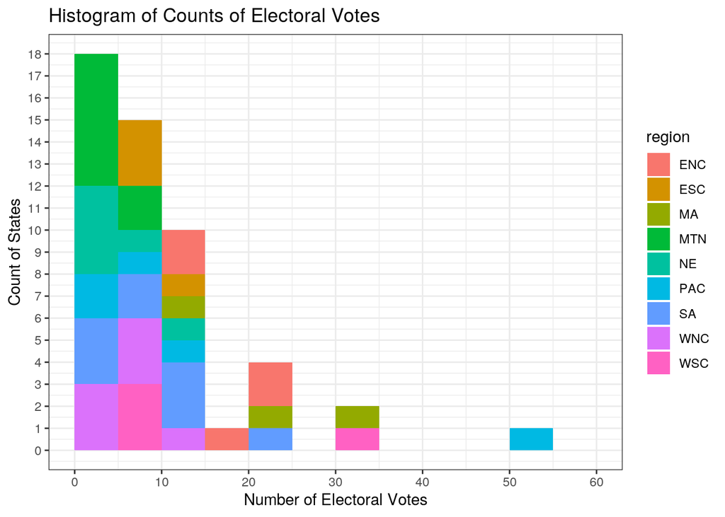

```r
# your plot 1
EduElect %>% ggplot(aes(x = Electoral_Votes)) + geom_histogram(aes(fill = region),
    breaks = seq(0, 60, 5)) + scale_x_continuous(breaks = seq(0,
    60, 10)) + scale_y_continuous(breaks = seq(0, 20, 1)) + ggtitle("Histogram of Counts of Electoral Votes") +
    xlab("Number of Electoral Votes") + ylab("Count of States") +
    theme_bw()
```

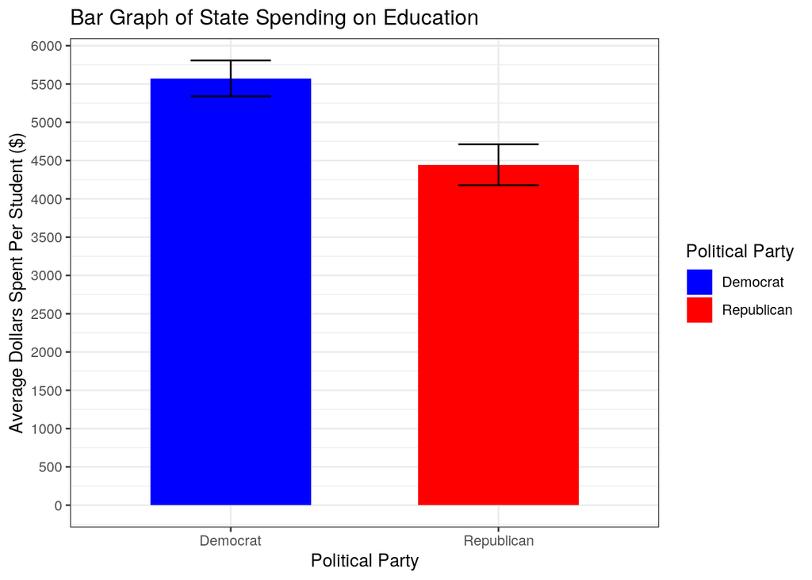

```r
# your plot 2
EduElect %>% ggplot(aes(x = Party_Voted, y = State_Spending)) +
    geom_bar(aes(y = State_Spending, fill = Party_Voted, width = 0.6),
        stat = "summary", fun = mean) + geom_errorbar(stat = "summary",
    fun.data = mean_se, width = 0.3) + scale_fill_manual("Political Party",
    values = c(Democrat = "blue", Republican = "red")) + scale_y_continuous(breaks = seq(0,
    6000, 500)) + ggtitle("Bar Graph of State Spending on Education") +
    xlab("Political Party") + ylab("Average Dollars Spent Per Student ($)") +
    theme_bw()
```

The second plot I made was a bar graph on average state spending on education. I grouped my bars based on Political party and saw that Democratic States spend on average ~$5500 per student on public education while Republican states spend on average ~$4500 per student on public education. The error bars show me that even accounting for SE, Democratic states still spend more than Republican states on average on public education.

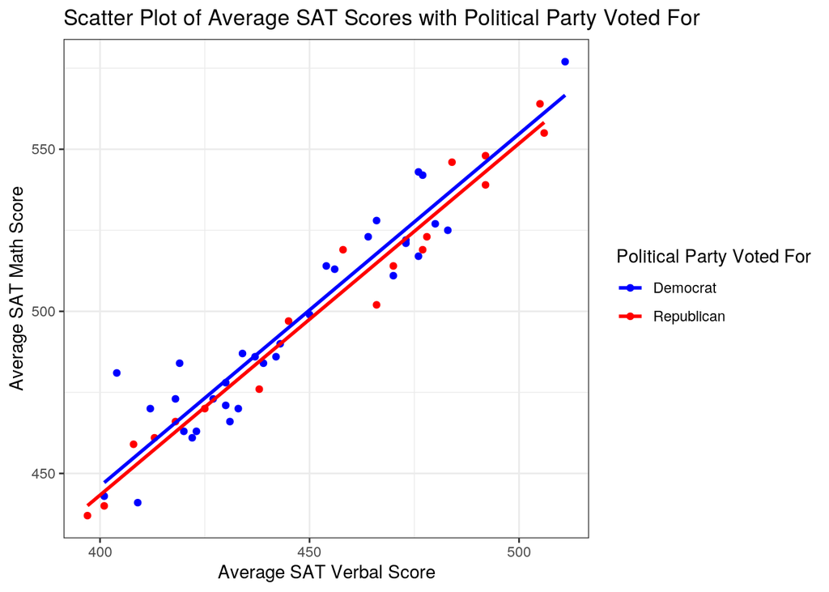

```r
# your plot 3
EduElect %>% ggplot(aes(x = SATV, y = SATM)) + geom_point(aes(color = Party_Voted)) +
    geom_smooth(aes(group = Party_Voted, color = Party_Voted),
        method = "lm", se = FALSE) + scale_color_manual("Political Party Voted For",
    values = c(Democrat = "blue", Republican = "red")) + theme_bw() +
    scale_x_continuous(breaks = seq(350, 550, 50)) + scale_y_continuous(breaks = seq(400,
    600, 50)) + ggtitle("Scatter Plot of Average SAT Scores with Political Party Voted For") +
    xlab("Average SAT Verbal Score") + ylab("Average SAT Math Score")
```

The third plot I made was a scatter plot which plotted the average SAT verbal score per state on the X axis and the average SAT math score per state on the Y axis while grouping by political party of each state. The scatter plot shows a strong, positive and linear relationship between average SAT verbal and math scores. The grouping of political parties shows there is no strong correlation that the states political party is correlated to both verbal or math SAT scores.